# TM og STM

Yuri Kasahara

2024-03-12

# 1 Topic Modelling og Structural Topic Modelling

## 1.1 Hva er de?

Topic modelling er en form for uveiledet maskinlæring som brukes til å oppdage de skjulte tematiske strukturene i store tekstkorpora. Metoden analyserer samlingene av tekster for å identifisere gjentagende mønstre av ord som representerer temaer. I stedet for å kreve forhåndsdefinerte kategorier eller etiketter, oppdager topic modelling statistiske grupperinger av ord (og dermed “topics”) som fremkommer fra korpora selv. Dette gjør metoden særlig nyttig for å utforske store tekstuelle datasett hvor de underliggende tematiske strukturene ikke er kjent på forhånd. De mest kjente algoritmene for topic modelling inkluderer Latent Dirichlet Allocation (LDA) og Non-negative Matrix Factorization (NMF). Tema-modellering har blitt anvendt i en rekke felt, fra digital humaniora til markedsforskning, for å avdekke innsikt i store tekstuelle data som ikke lett lar seg observere gjennom manuell gjennomgang.

Structural Topic Modelling er en variant av Topic Modelling som benyttes av metadata koblet til teksten. I utgangspunkt, bruker ikke vanlig LDA eller NMF informasjon som vi kan ha om tekster/korpora. Informasjon som forfatter, dato av publisering og forlag brukes aktivt i estimeringen av temaer ved å bruke STM.

## 1.2 Viktig å vite

- Topic modelling trenger et antall temaer som skal organiseres på forhånd. Det finnes ikke et “riktig” antall av temaer.
- Temaer gir ikke nødvendigvis mening. Forsker må alltid sjekke de genererte temaer for å se om de gir mening.
- De fleste TM algoritmer er sannsynlighetsbasert. Huske å “seed” din modellen for å sikre at det kan repliseres.

## 1.3 Intuisjon bak LDA og andre sannsynlighetsbasert topic models

- Dokumenter er sannsynlighetsfordelinger av latente variabler (topics).
- Topics er sannsynlighetsfordelinger av ord.
- Hver dokument har et bestemt antall temaer.
- LDA og varianter bruker “bag of words” tilnærming til tekst - ikke hensyn til kontekst.

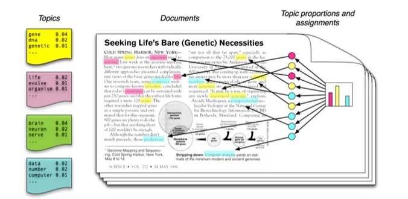

Source: Blei, D. M. (2012), Probabilistic Topic Models

# 2 Biblioteker og data vi skal bruke

```r
library(tm)
library(topicmodels)
library(stm)
library(tidyverse)
library(quanteda)
library(stopwords)
library(tidytext)
```

```r
info_reports_SVA_with_lang <- read.csv("info_reports_SVA_with_lang.csv", encoding = "UTF-8")
```

Data burde ser som ut.

| Title | Abstract | Institute | Year | doc_lang | doc_lang_score |
| --- | --- | --- | --- | --- | --- |
| Bærekraftig befolkningsutvikling og grønn distriktsomstilling | Rapporten handler om bærekraftig befolkningsutvikling i distriktskommuner og hvilke faktorer for attraktivitet og kompetanse som kan bidra til grønn omstilling. Rapporten beskriver indikatorer som dis… | NIBR | 2023 | no | 0.6635555 |
| Risikovurdering og reintegrering av radikaliserte individer i Norden | Rapporten belyser arbeidet med risikovurdering og reintegrering av radikaliserte individer i de fire nordiske landene, Danmark, Sverige, Norge og Finland. Vi har intervjuet praktikere og andre myndigh… | NIBR | 2023 | no | 0.6111107 |

# 3 Prossesering av tekster

La oss beholde bare sammendrag på norsk og nynorsk

```r
info_reports_SVA_no <- info_reports_SVA_with_lang %>% filter(info_reports_SVA_with_lang$doc_lang == "no" |    info_reports_SVA_with_lang$doc_lang == "nn")
```

La oss forvandle variabler type for bedre behandling

```r
info_reports_SVA_no$Institute <- as.factor(info_reports_SVA_no$Institute)
info_reports_SVA_no$Year <- as.numeric(info_reports_SVA_no$Year)
```

La oss bruke quanteda for å lage vår korpora fil.

```r
SVA_corpus <- corpus(info_reports_SVA_no, text_field="Abstract")

summary(SVA_corpus)
```

Vi trenger å lage en “document-feature matrix” for å kjøre en topic model!

```r
# Ved å bruke dfm funksjon kan vi fjerne andre symboler og ordene som ikke er nyttige
SVA_corpus_dfm <- dfm(SVA_corpus, remove_numbers=TRUE, remove_punct=TRUE, remove_symbols=TRUE, remove = c(stopwords("no"), stopwords("en")))

SVA_corpus_dfm
```

```
## Document-feature matrix of: 1,503 documents, 21,831 features (99.72% sparse) and 5 docvars.
##        features
## docs    rapporten handler bærekraftig befolkningsutvikling distriktskommuner
##   text1         2       1           1                    1                 2
##   text2         1       0           0                    0                 0
##   text3         1       0           0                    0                 0
##   text4         0       0           0                    0                 0
##   text5         1       0           0                    0                 0
##   text6         0       0           0                    0                 0
##        features
## docs    faktorer attraktivitet kompetanse bidra grønn
##   text1        1             1          1     1     1
##   text2        0             0          0     0     0
##   text3        0             0          0     0     0
##   text4        0             0          0     0     0
##   text5        0             0          2     0     0
##   text6        0             0          1     0     0
## [ reached max_ndoc ... 1,497 more documents, reached max_nfeat ... 21,821 more features ]
```

Vi kan redusere vår DFM ved å slette mest/minst frekvent ord.

```r
SVA_corpus_dfm.trim <- dfm_trim(SVA_corpus_dfm, min_termfreq = 2, max_termfreq = 75)

SVA_corpus_dfm.trim
```

```
## Document-feature matrix of: 1,503 documents, 9,737 features (99.60% sparse) and 5 docvars.
##        features
## docs    bærekraftig befolkningsutvikling distriktskommuner faktorer
##   text1           1                    1                 2        1
##   text2           0                    0                 0        0
##   text3           0                    0                 0        0
##   text4           0                    0                 0        0
##   text5           0                    0                 0        0
##   text6           0                    0                 0        0
##        features
## docs    attraktivitet omstilling indikatorer benytte følge overvåke
##   text1             1          1           1       1     1        1
##   text2             0          0           0       0     0        0
##   text3             0          0           0       0     0        0
##   text4             0          0           0       0     0        0
##   text5             0          0           0       0     0        0
##   text6             0          0           0       0     0        0
## [ reached max_ndoc ... 1,497 more documents, reached max_nfeat ... 9,727 more features ]
```

# 4 Enkel Topic Model med LDA

Nå skal vi trene en modell.

```r
# Antall temaer må defineres
n_topics <- 4

# Forvandle matrisen til en LDA format
dfm2topicmodel <- convert(SVA_corpus_dfm.trim, to="topicmodels")

# Kjøre modellen. Det kan ta tid avhengig av hvor mange temaer du kjører.
lda.model <- LDA(dfm2topicmodel, n_topics, control = list(seed=1710249719))

#La oss visualisere ordene per tema
model_topics <- as.data.frame(terms(lda.model, 4))

# På en bedre måte

model_topics <- tidy(lda.model, matrix = "beta")
model_topics
```

```
## # A tibble: 38,948 × 3
##    topic term                      beta
##    <int> <chr>                    <dbl>
##  1     1 bærekraftig          7.48e-  4
##  2     2 bærekraftig          1.79e-  4
##  3     3 bærekraftig          1.17e-  3
##  4     4 bærekraftig          5.00e- 19
##  5     1 befolkningsutvikling 1.26e-  4
##  6     2 befolkningsutvikling 1.53e-111
##  7     3 befolkningsutvikling 2.10e-  4
##  8     4 befolkningsutvikling 3.63e- 30
##  9     1 distriktskommuner    4.74e-  4
## 10     2 distriktskommuner    4.81e-107
## # … with 38,938 more rows
```

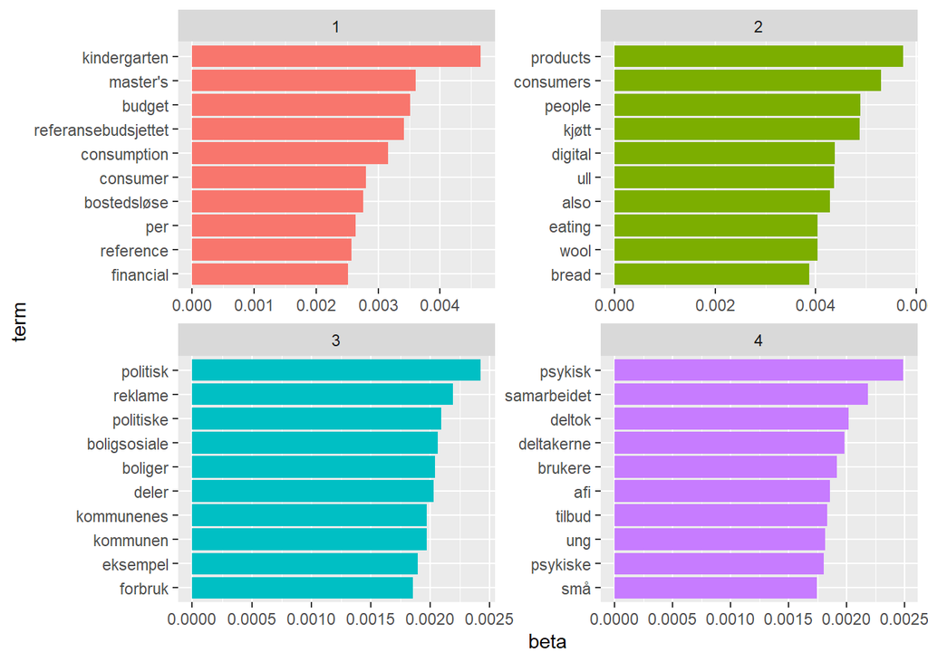

```r
top_terms <- model_topics %>%
  group_by(topic) %>%
  slice_max(beta, n = 10) %>%
  ungroup() %>%
  arrange(topic, -beta)

top_terms %>%
  mutate(term = reorder_within(term, beta, topic)) %>%
  ggplot(aes(beta, term, fill = factor(topic))) +
  geom_col(show.legend = FALSE) +
  facet_wrap(~ topic, scales = "free") +
  scale_y_reordered()
```

Vi kan også sjekke fordelling av dokumenter per tema.

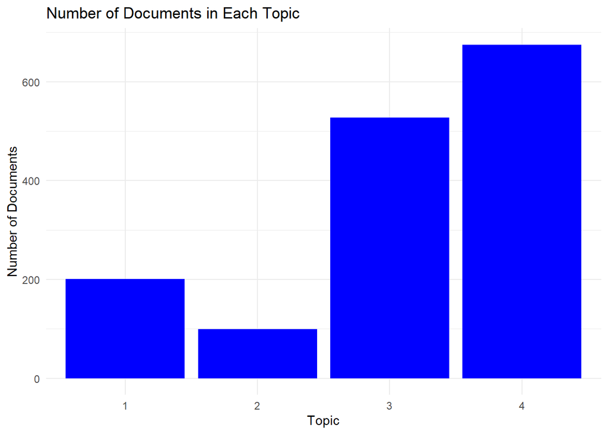

```r
#Ta gamma values fra lda.model outuput

gamma_values <- as.data.frame(lda.model@gamma)

# Få bare den høyeste gamma verdi per dokument
max_topic_per_document <- apply(gamma_values, 1, which.max)

# Lage en dataset med telling av dokumenter per topic
topic_counts <- as.data.frame(table(MaxTopic = max_topic_per_document))

# La oss lage en figur for å se
ggplot(topic_counts, aes(x = MaxTopic, y = Freq)) +
  geom_bar(stat = "identity", fill = "blue") +
  theme_minimal() +
  labs(title = "Number of Documents in Each Topic",
       x = "Topic",
       y = "Number of Documents")
```

Vi kan også se resultater for enkel dokument

```r
topics_dokumenter <- tidy(lda.model, matrix = "gamma")
topics_dokumenter
```

```
## # A tibble: 6,008 × 3
##    document topic    gamma
##    <chr>    <int>    <dbl>
##  1 text1        1 0.991
##  2 text2        1 0.00187
##  3 text3        1 0.000978
##  4 text4        1 0.00534
##  5 text5        1 0.00129
##  6 text6        1 0.00212
##  7 text7        1 0.00152
##  8 text8        1 0.995
##  9 text9        1 0.994
## 10 text10       1 0.00285
## # … with 5,998 more rows
```

```r
#fordelinger av temaer på text1
topics_dokumenter %>% filter(document == "text1") %>%
  arrange(desc(gamma))
```

```
## # A tibble: 4 × 3
##   document topic   gamma
##   <chr>    <int>   <dbl>
## 1 text1        1 0.991
## 2 text1        3 0.00303
## 3 text1        4 0.00303
## 4 text1        2 0.00303
```

```r
#Vi kan se også de ordene i den dokumenten
tidy(SVA_corpus_dfm.trim) %>%
  filter(document == "text1") %>%
  arrange(desc(count))
```

```
## # A tibble: 15 × 3
##    document term                 count
##    <chr>    <chr>                <dbl>
##  1 text1    distriktskommuner        2
##  2 text1    bærekraftig              1
##  3 text1    befolkningsutvikling     1
##  4 text1    faktorer                 1
##  5 text1    attraktivitet            1
##  6 text1    omstilling               1
##  7 text1    indikatorer              1
##  8 text1    benytte                  1
##  9 text1    følge                    1
## 10 text1    overvåke                 1
## 11 text1    samfunnsutvikling        1
## 12 text1    områdene                 1
## 13 text1    empiriske                1
## 14 text1    grunnlaget               1
## 15 text1    harstad                  1
```

## 4.1 Men hvordan kan vi si at vi har en god modell?

```r
train = sample(rownames(dfm2topicmodel), nrow(dfm2topicmodel) * .75)
dtm_train = dfm2topicmodel[rownames(dfm2topicmodel) %in% train, ]
dtm_test = dfm2topicmodel[!rownames(dfm2topicmodel) %in% train, ]

m = LDA(dtm_train, method = "Gibbs", k = 5,  control = list(alpha = 0.01))

perplexity(m, dtm_test)
```

```
## [1] 5364.835
```

Men vi trenger flere målinger for å vite hvor godt den modellen er.

```r
## Lage en datasett for å lagre "perplexity scores" for forskjellige verdier av k
p = data.frame(k = c(2,4,8,16,32,64,128), perplexity = NA)

## "loop" over k verdier i datasett p
for (i in 1:nrow(p)) {
  print(p$k[i])
  ## beregne perplexity for hver k verdi
  m = LDA(dtm_train, method = "Gibbs", k = p$k[i],  control = list(alpha = 0.01))
  ## lagre resultater i datasett p
  p$perplexity[i] = perplexity(m, dtm_test)
}
```

```
## [1] 2
## [1] 4
## [1] 8
## [1] 16
## [1] 32
## [1] 64
## [1] 128
```

Nå kan vi visualisere resultatene

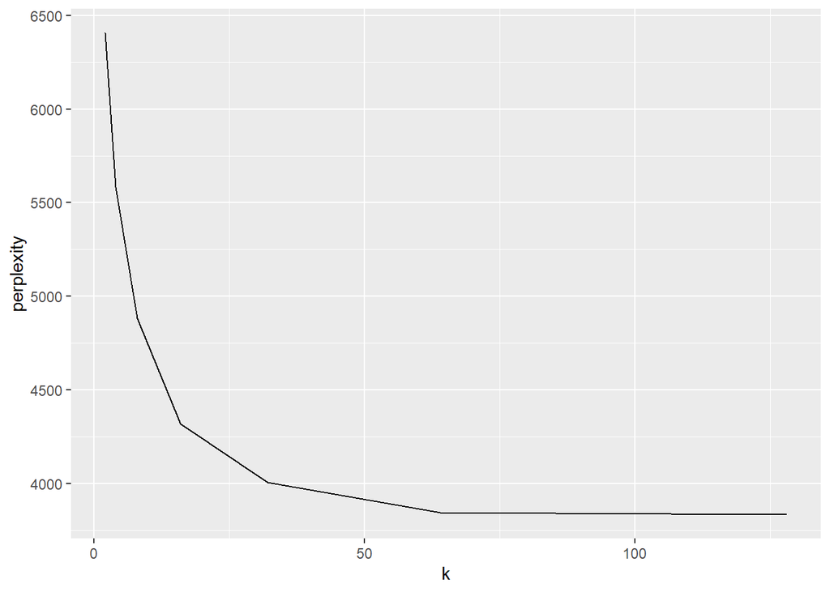

```r
ggplot(p, aes(x=k, y=perplexity)) + geom_line()
```

Kanskje 16 er noe bedre?